# Purpose

This method performs enrichment analysis’ on proteins that have been binned for abundance X disorder.

What is being “Enriched” is the user’s choice. Some examples are:

1. Overexpression
2. Haploinsufficiency
3. Phase Separation
4. Phase Separating Clients
5. Phase Separating Drivers

Enrichments are calculated using Fisher Exact Tests. The background for the tests are “Enrichment” in the Proteome.

# Function Documentation

All functions for this method can be found in:

’scripts/enrichment_summary_functions.R”

# Method Walkthrough

To outline the method, we will be using the 5x5 binned yeast genome created in Bin_Genes.Rmd (see Bin_Genes.html).

## 1.Setup

Run setup files and access functions

```r
library(tidyverse)
```

```r
library(ggplot2)
library(knitr)
library(RColorBrewer)
library(pheatmap)

source('scripts/enrichment_summary_functions.R')
```

## 2. Open 5x5 Abundance X Disorder Yeast Bins and Master Data Frame

The abundance X disorder bins were generated in Bin_Genes.Rmd For a thorough understanding of the abundance X disorder bins, please see Bin_Genes.Rmd

**binned_genes:** : The abundance X disorder bins. A list of data frames where each data frame is an abundance X disorder bin.

**master** : **master**: Dataframe containing yeast protein data

```r
binned_genes <- readRDS(file = 'data/Rmd_example_data/5x5_yeast_matrix.rds')
master <- read.delim(file = 'data/merged_tables/yeast/actual_master.tsv', sep = "\t")

print(paste('Size of Master Data Frame: ', nrow(master)))
```

```
## [1] "Size of Master Data Frame:  6730"
```

## 3. Define Global Parameters

Identify the column name of what property you are assessing enrichment for.

In our walkthrough example, we are calculating enrichment of **Haploinsuffient Genes**.

**enrichment_column:** The name of the column which contains the enrichment property of interest

**alpha:** The alpha value for downstream Fisher Exact Tests

**abundance_col** : The name of the column which contains abundance information

**disorder_col** : The name of the column which contains disorder information

**abundance_groups** :The number of abundance groups to split the proteome into. This must be the same number as you used to create binned_genes.

**disorder_groups** : The number of disorder groups to split the proteome into. This must be the same number as you used to create binned_genes.

```r
enrichment_column <-  'HI'
alpha <- 0.01
disorder_col <-  'disopred3perc'
abundance_col <-  'abundance'
abundance_groups <-  5
disorder_groups <-  5
```

## 4. Preliminary Filtering of Yeast Proteome

Perform some preliminary filtering of the yeast master data frame

1. log2+1 transform abundance scores
2. Remove proteins that lack abundance OR disorder scores

```r
master$abundance <- log2(master$abundance+1)

master <- filter(master,
                 !is.na(!!sym(abundance_col)) & !is.na(!!sym(disorder_col)))
print(paste('Size of Master Data Frame: ', nrow(master)))
```

```
## [1] "Size of Master Data Frame:  5939"
```

| uniprot_id | disopred3perc | iupredperc | abundance | uniprot_symbols | entrez_id | HI | OE | new_oe | drlps_drivers | drpls_clients | dr_all_phase_sep |
| --- | --- | --- | --- | --- | --- | --- | --- | --- | --- | --- | --- |
| P0CX20 | 22.43 | 12.13 | 1.321928 | YRF1-1 YDR545W D3703.4 | NA | NA | NA | NA | NA | NA | NA |
| P40509 | 0.33 | 0.00 | 8.118941 | SEC28 YIL076W | NA | NA | NA | NA | NA | NA | NA |
| P00427 | 27.02 | 0.00 | 8.276124 | COX6 YHR051W | NA | NA | NA | NA | NA | NA | NA |
| Q03063 | 89.60 | 81.85 | 4.572890 | DIG1 RST1 YPL049C P7102.02 | NA | NA | NA | NA | NA | NA | NA |
| P19659 | 70.49 | 68.36 | 4.459432 | GAL11 ABE1 MED15 RAR3 SDS4 SPT13 YOL051W | YOL051W | NA | 1 | NA | NA | NA | NA |

## 5. Calculate Enrichment of the Proteome

As a background in our enrichment analysis within each bin, we will use the enrichment in the proteome.

Using the entire proteome the following is identified:

1. The number of proteins in the proteome.
2. The number of ‘enrichment’ proteins in the proteome. In our example, we are counting the number of proteins in the proteome that are Haploinsufficient.
3. The number of ‘non-enrichment’ proteins that are in the proteome. In our example, we are counting the number of proteins in the proteome that are not haploinsufficient.

The information is saved in a 1x3 data frame. Convenient or the downstream Fisher Test  
**proteome_enrichment:** Dataframe containing information about enrichment of a given property in the proteome

```r
proteome_enrichment <- summarize_enrichment(master, enrichment_column)
```

| total | counts | not_counts |
| --- | --- | --- |
| 5939 | 170 | 5769 |

## 6.Calculate the Enrichment in Abundance X Disorder Bins

We need to count the number of enriched proteins in each of the abundance X disorder bins.

In each bin the following is identified:

1. The number of proteins in the bin.
2. The number of ‘enrichment’ proteins that are in the bin. In our example, we are counting the number of proteins in the bin that are Haploinsufficient.
3. The number of ‘non-enrichment’ proteins that are in the bin. In our example, we are counting the number of proteins in the bin that are not Haploinsufficient.  
   **enrichment_list:** List of dataframes. Each dataframe contains information about enrichment of a given property in an abundance X disorder bin.

```r
enrichment_list <- lapply(binned_genes, summarize_enrichment, enrichment_column)
```

#### Looking at the enrichment_list

enrichment_list is a list of data frames of the same length as binned_genes.

In each of these data frames, the amount of proteins who display the named enrichment property in that bin has been counted

```
## [1] "The Length of enrichment_list: 25"
```

#### Example of Enrichment in Low Disorder Low Abundance Bin

| total | counts | not_counts |
| --- | --- | --- |
| 348 | 0 | 348 |

#### Example of Enrichment in High Disorder High Abundance Bin

| total | counts | not_counts |
| --- | --- | --- |
| 118 | 13 | 105 |

## 7.Append the Proteome Enrichment to Each DataFrame in enrichment_list

In preparation for the fisher exact test, append the proteome enrichment.

```r
enrichment_list <- lapply(enrichment_list, rbind, proteome_enrichment)
```

### Example of Enrichment in Low Disorder Low Abundance Bin

| total | counts | not_counts |
| --- | --- | --- |
| 348 | 0 | 348 |
| 5939 | 170 | 5769 |

### Example of Enrichment in High Disorder High Abundance Bin

| total | counts | not_counts |
| --- | --- | --- |
| 118 | 13 | 105 |
| 5939 | 170 | 5769 |

## 8. Calculate Effect Size

Prior to performing a Fisher Excact Test, it is usefull to calculate the effect size of each enrichment

**Effect size in proteome is calculated by:**

number of proteins displaying enriched property in the proteome / number of proteins in proteome

**Effect size in a bin is calculated by:**

number of proteins displaying enriched property in the bin / number of proteins in bin

```r
enrichment_list <- lapply(enrichment_list, get_effect_size)
```

### Example of Enrichment in Low Disorder Low Abundance Bin

| total | counts | not_counts | effect_size |
| --- | --- | --- | --- |
| 348 | 0 | 348 | 0.0000000 |
| 5939 | 170 | 5769 | 0.0286243 |

### Example of Enrichment in High Disorder High Abundance Bin

| total | counts | not_counts | effect_size |
| --- | --- | --- | --- |
| 118 | 13 | 105 | 0.1101695 |
| 5939 | 170 | 5769 | 0.0286243 |

## 9. Perform Fisher Exact Test

In each abundance bin, we perform a 2x2 Fisher Exact Test.

Note: Non-relevant columns are automatically removed so that all data frames are 2x2

**enrichment_p_values:** A List of P values. Each P value was generated by performing a fisher exact test in an abundance X disorder bin

```r
enrichment_p_values <- lapply(enrichment_list, get_p_value, alpha = alpha)
kable(unlist(enrichment_p_values))
```

|  | x |
| --- | --- |
| 1,1.counts | 1.0000000 |
| 1,2.counts | 0.9996105 |
| 1,3.counts | 1.0000000 |
| 1,4.counts | 0.9719484 |
| 1,5.counts | 1.0000000 |
| 2,1.counts | 1.0000000 |
| 2,2.counts | 0.9962101 |
| 2,3.counts | 0.9565535 |
| 2,4.counts | 0.9953940 |
| 2,5.counts | 0.9972662 |
| 3,1.counts | 0.8583651 |
| 3,2.counts | 0.9813769 |
| 3,3.counts | 0.9547039 |
| 3,4.counts | 0.7933472 |
| 3,5.counts | 0.9998822 |
| 4,1.counts | 0.8875873 |
| 4,2.counts | 0.6807180 |
| 4,3.counts | 0.3915254 |
| 4,4.counts | 0.0997610 |
| 4,5.counts | 0.4965559 |
| 5,1.counts | 0.0001169 |
| 5,2.counts | 0.0000000 |
| 5,3.counts | 0.0010703 |
| 5,4.counts | 0.0017813 |
| 5,5.counts | 0.0000495 |

# Visualization

## Visualizing Effect Size

To visualize effect size, you need to create a matrix of effect sizes

```r
effect_sizes <- unlist(lapply(enrichment_list, pull_effect_sizes))

effect_size_matrix <- matrix(effect_sizes*100,
                             nrow =  disorder_groups,
                             ncol = abundance_groups)

# Flips the matrix over its horizontal plane so that the highest disorder highest abundance bin is top right
effect_size_matrix <- ((effect_size_matrix [ c(nrow(effect_size_matrix) : 1) , ]))

kable(effect_size_matrix)
```

| 0.0000000 | 0.8522727 | 0.3144654 | 3.030303 | 11.016949 |
| --- | --- | --- | --- | --- |
| 1.0582011 | 0.7604563 | 2.1978022 | 4.428044 | 7.291667 |
| 0.0000000 | 1.3274336 | 1.3392857 | 3.257329 | 7.174888 |
| 0.3636364 | 0.5154639 | 0.9708738 | 2.500000 | 12.460064 |
| 0.0000000 | 0.0000000 | 1.7964072 | 1.675978 | 7.038123 |

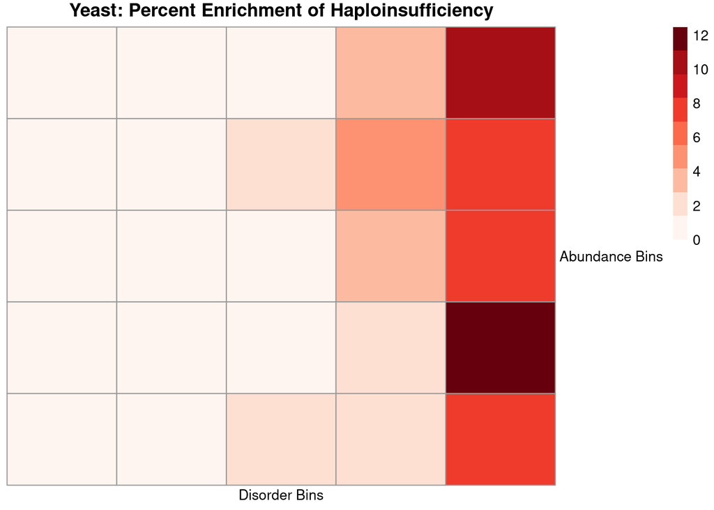

```r
pheatmap(mat = effect_size_matrix,
         main = paste0("Yeast: Percent Enrichment of Haploinsufficiency"),
         cluster_cols = FALSE,
         cluster_rows = FALSE,
         color = brewer.pal(n = 9, name = 'Reds'),
         legend = TRUE,
         annotation_legend = TRUE,
         legend_labels = c(5,1,3,3,6),
         show_rownames = TRUE,
         labels_col = 'Disorder Bins',
         labels_row = 'Abundance Bins',
         angle_col = 0,
         angle_row = 90
)
```

## Visualizing Significant Enrichments

To visualize what p_values are significant you need to create a matrix of pvalues

```r
p_values_double <- unlist(enrichment_p_values)
p_value_matrix <- matrix(p_values_double,
                         ncol = abundance_groups,
                         nrow = disorder_groups)

# Flips the matrix over its horizontal plane so that the highest disorder highest abundance bin is top right
p_value_matrix <- ((p_value_matrix[ c(nrow(p_value_matrix) : 1) , ]))
kable(p_value_matrix)
```

| 1.0000000 | 0.9972662 | 0.9998822 | 0.4965559 | 0.0000495 |
| --- | --- | --- | --- | --- |
| 0.9719484 | 0.9953940 | 0.7933472 | 0.0997610 | 0.0017813 |
| 1.0000000 | 0.9565535 | 0.9547039 | 0.3915254 | 0.0010703 |
| 0.9996105 | 0.9962101 | 0.9813769 | 0.6807180 | 0.0000000 |
| 1.0000000 | 1.0000000 | 0.8583651 | 0.8875873 | 0.0001169 |

Red bins indicate that enrichment is significant

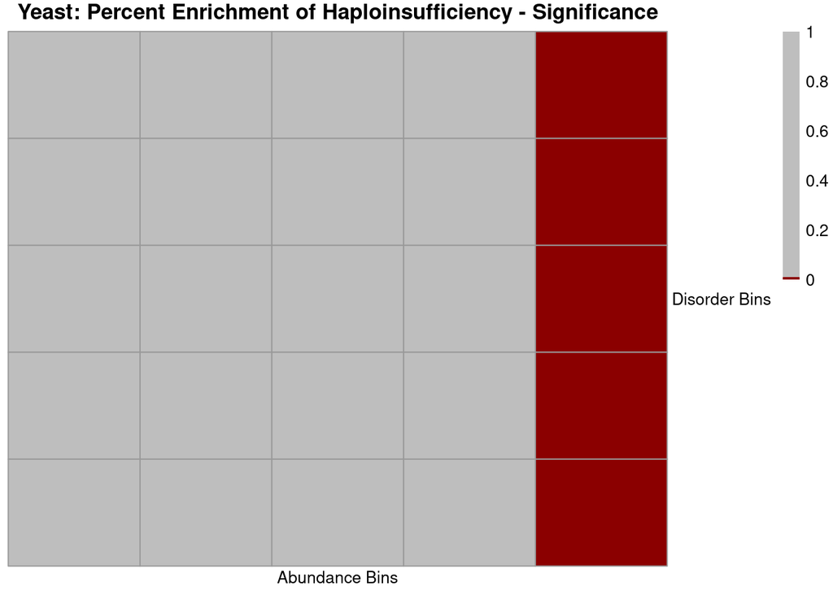

```r
pheatmap(mat = p_value_matrix,
         main = paste0("Yeast: Percent Enrichment of Haploinsufficiency - Significance"),
         breaks = c(0, alpha, 1),
         cluster_cols = FALSE,
         cluster_rows = FALSE,
         color = c('red4', 'grey'),
         labels_col = 'Abundance Bins',
         labels_row = 'Disorder Bins',
         angle_col = 0,
         angle_row = 90
)
```

## Visualizing P Values

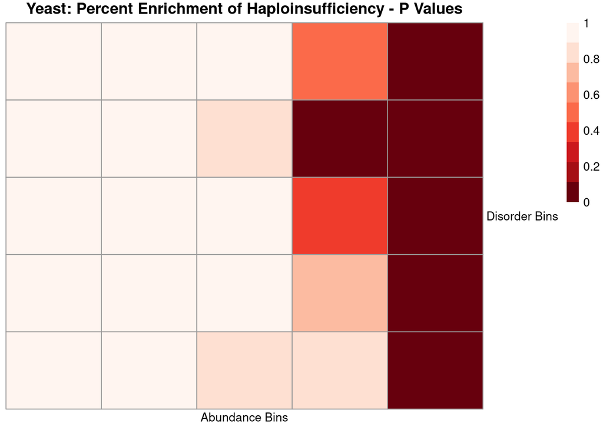

```r
pheatmap(mat = (p_value_matrix),
         main = paste0("Yeast: Percent Enrichment of Haploinsufficiency - P Values"),
         cluster_cols = FALSE,
         cluster_rows = FALSE,
         color = rev(brewer.pal(n = 9, name = 'Reds')),
         labels_col = 'Abundance Bins',
         labels_row = 'Disorder Bins',
         angle_col = 0,
         angle_row = 90
)
```